# Analysis supplement: Validation of the P3CEQ.

Ben Fosh, Ben Whalley

# Setup

### Package requirements

We use the checkpoint library to snapshot package versions:

```r
# chpt <- checkpoint::checkpoint("2018-07-01")
library(eRm)
library(tidyverse)
library(pander)
```

### Setup and data processing

Import data:

```r
# XXX BEN - note I have changed to use relative paths... this is best practice and makes it easier to replicate for others.
raw_data <- read_csv("rawdata.csv")
# isolate items from data frame
items <- raw_data %>% select(Q1, Q2, Q3, Q4, Q5, Q6, Q7, Q8, Q8b, Q8c, Q8d, Q9, Q10, Q11)

# check data starts from 0
# XXX BEN YOU NEED TO EXPLAIN THIS CODE IN A COMMENT.. IT's weird-- why do this? Were some items recorded incorrectly? What
for(i in 1:ncol(items)){
  if(0%in%items[,i]==FALSE){
    items[, i] = items[,i] - 1
}}
```

XXX WHAT about cases where you subtracted one from the column above… does this interact with the code below? Would seem to create an off-by-one for some columns?

```r
# Rescore response 99 (don't know) to 0
items[items >= 98] <- 0

# Rescore item 4 responses  to 3
items$Q4[items$Q4 >3] <- 3
```

Remove rows where only 1 item available:

```r
qs <- items %>%
  filter(rowSums(is.na(.)) < (ncol(items)-1)) %>%
  # take mean of Q8 items a different way - see below
  mutate(q8newALT = rowMeans(select(., Q8, Q8b, Q8c, Q8d), na.rm=T))
```

XXX Could do with a comment here explainign why these questions combined XXX BEN - I’m also concerned about this line unless it’s deliberate:

```r
qs$q8new <- rowSums(qs[,c("Q8", "Q8b", "Q8c", "Q8d")], na.rm=TRUE) / 4
```

XXX The issue here is that you are summing then dividing by 4 to average, which effectively imputes a zero for the missing items. Is this what is wanted? the `q8newALT` variable above is the true mean of the available data, and this would create more missing values.

XXX See there is a real difference in computed score:

```r
round(qs$q8new, 0)-qs$q8newALT
```

```
##    [1]  1.0000000  1.0000000  1.0000000  1.0000000  1.0000000  0.0000000
##    [7]  0.0000000  0.0000000  1.0000000  0.0000000  1.0000000  1.0000000
##   [13]  1.0000000  0.0000000  1.0000000 -0.6666667  1.0000000  0.0000000
##   [19]  1.0000000 -1.0000000        NaN  1.0000000  1.0000000  1.0000000
##   [25]  1.0000000  0.0000000  0.0000000  1.0000000        NaN  0.0000000
##   [31]  1.0000000  1.0000000  0.2500000  1.0000000  1.0000000  0.0000000
##   [37]  1.0000000  1.0000000  0.2500000  1.0000000  0.2500000  1.0000000
##   [43]  1.0000000  0.2500000  1.0000000  1.0000000  1.0000000  1.0000000
##   [49]  0.5000000  0.2500000  1.0000000  1.0000000  1.0000000  1.0000000
##   [55]  0.0000000  1.0000000  1.0000000  1.0000000  1.0000000        NaN
##   [61]  1.0000000  1.0000000        NaN  1.0000000  1.0000000  1.0000000
##   [67]  0.0000000  1.0000000  0.0000000  1.0000000  0.0000000  1.0000000
##   [73]  1.0000000        NaN  1.0000000  1.0000000  0.5000000  1.0000000
##   [79]  1.0000000 -0.2500000  0.2500000  1.0000000  1.0000000  1.0000000
##   [85]  1.0000000  1.0000000  1.0000000  1.0000000 -0.5000000  0.0000000
```

[output cut: 377 more lines]

Write out transformed data:

```r
write.csv(qs, "qs.csv")
```

# Partial Credit Models

Runs the Partial Credit Model:

```r
qs.no <- qs %>% select(Q1, Q2, Q3, Q5, Q6, Q9, Q10, Q11)
qs.no.clean <- qs.no %>%
  mutate(nmiss=rowSums(is.na(.))) %>%
  # remove where only 1 item available
  # XXX haven't you already done this above? Perhaps remove 2 lines below
  filter(nmiss < (ncol(qs.no)-1)) %>%
  select(-nmiss)

pcm.2 <- eRm::PCM(qs.no.clean)
```

ICC plots

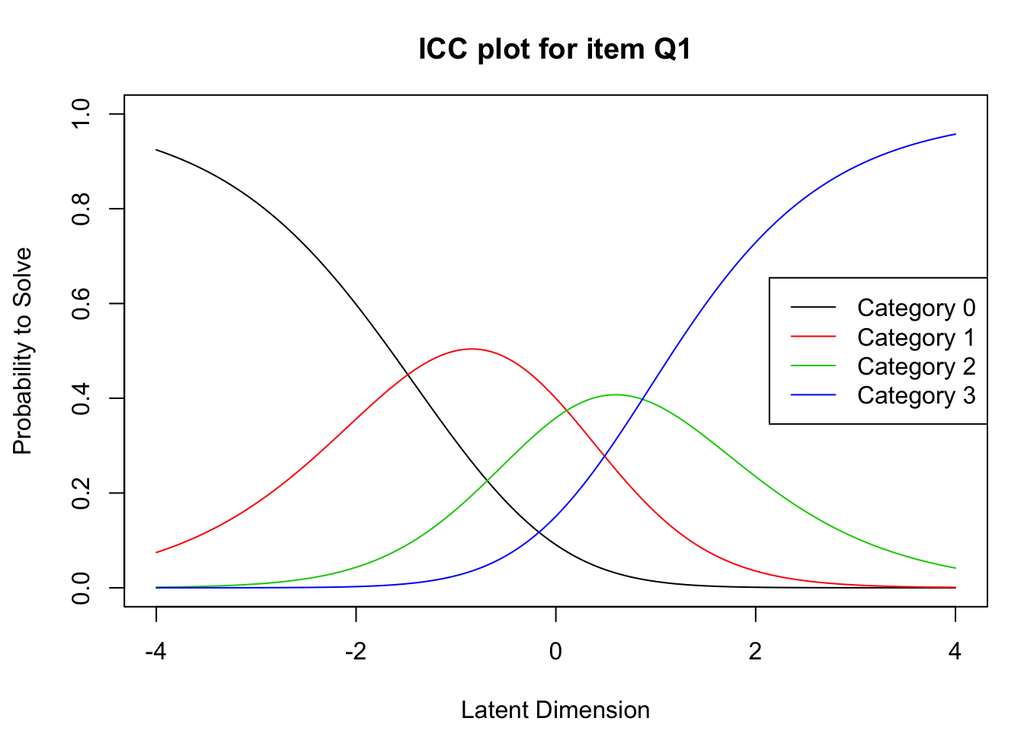

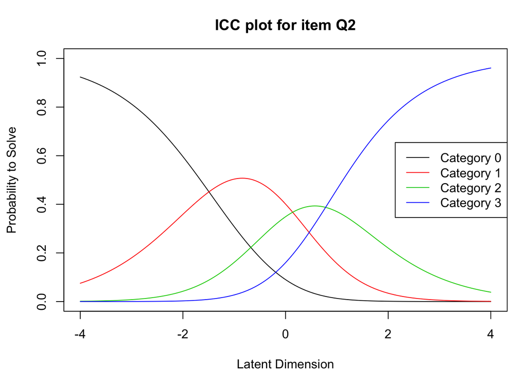

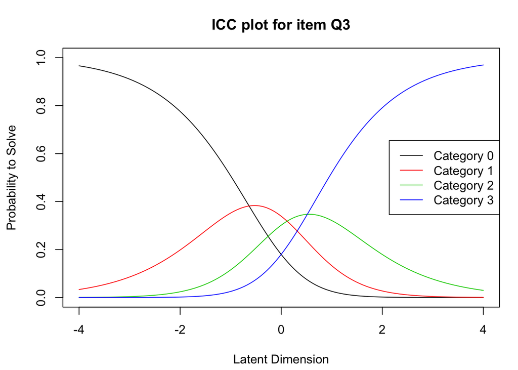

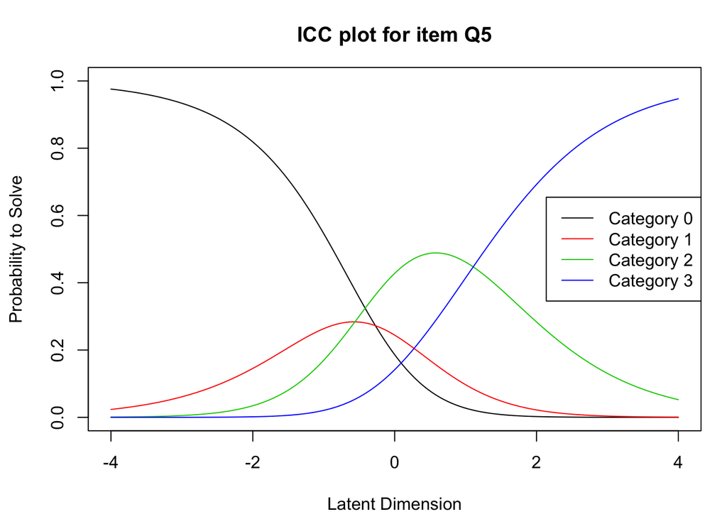

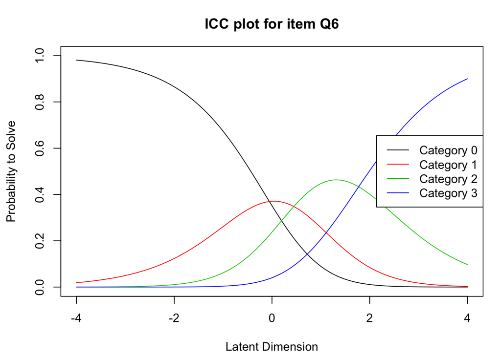

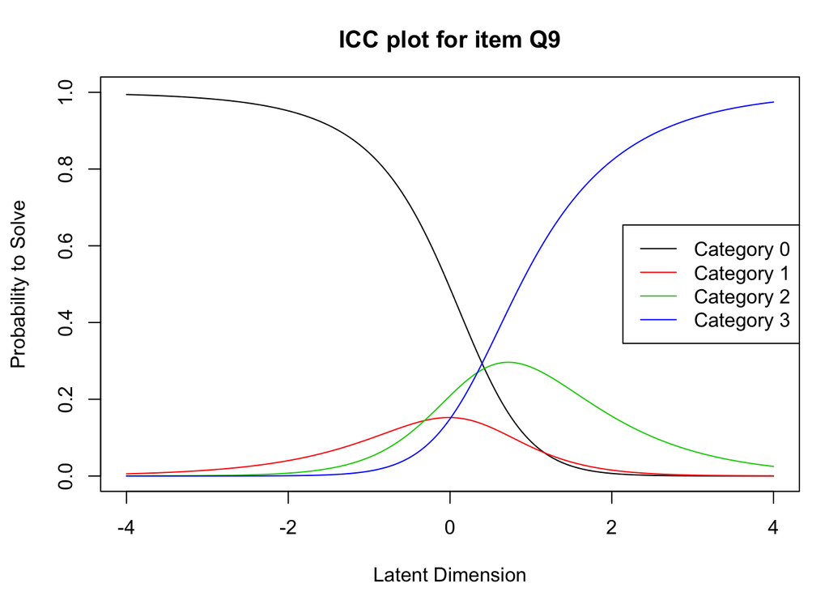

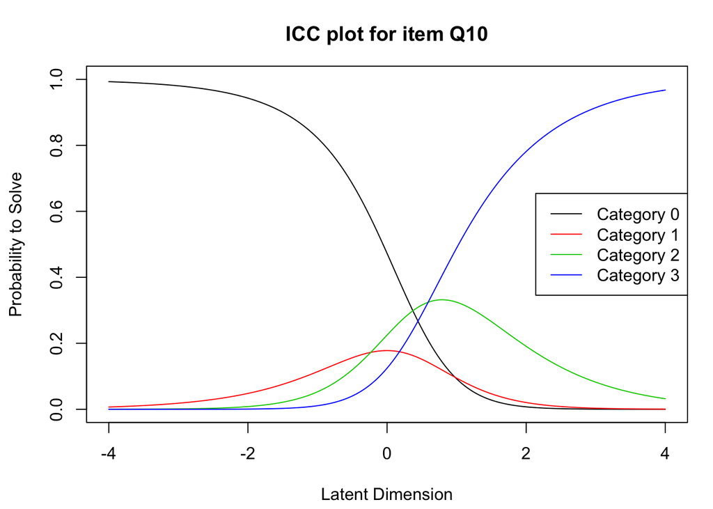

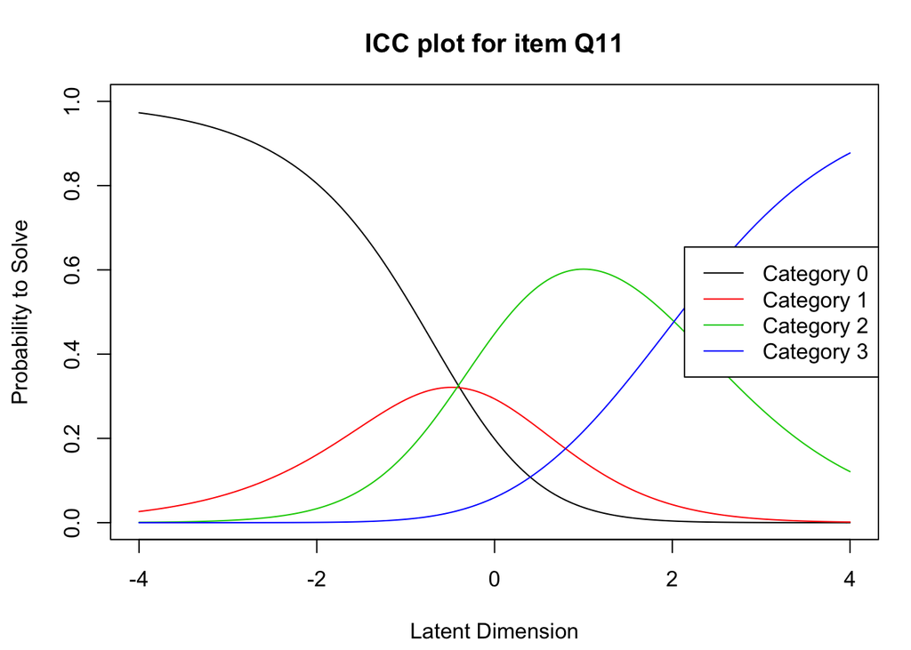

```r
# get ICC plots
plotICC(pcm.2, mplot = F, legpos = "right", ask = FALSE)
```

PI Plots:

```r
pcm2.pp <- person.parameter(pcm.2)
```

```
## Spline interpolation in some subgroups not performed!
##   Less than 4 different person parameters estimable!
##   Perhaps NAs in subgroup(s).
```

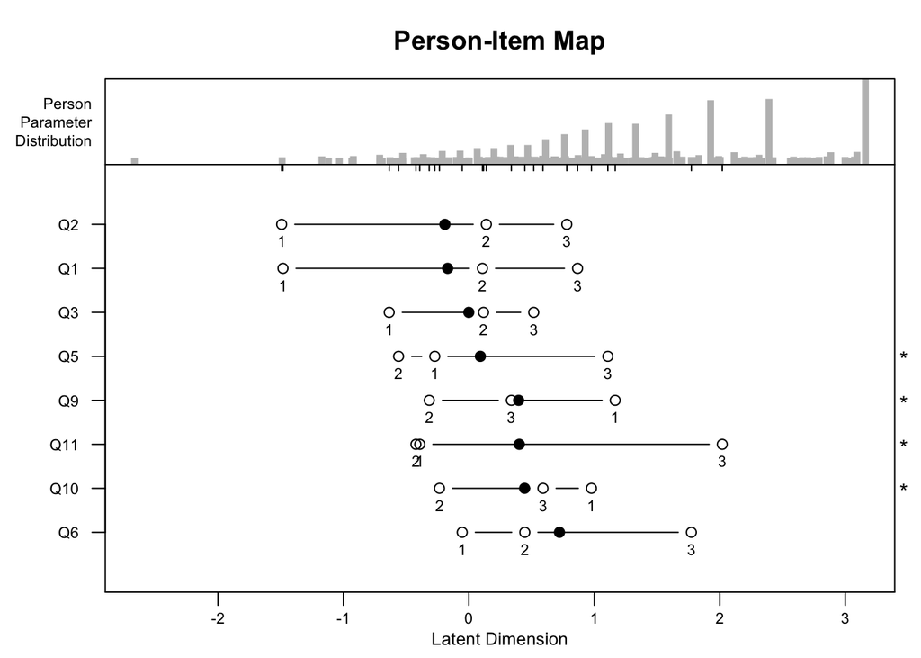

```r
plotPImap(pcm.2, sorted = TRUE, pp=pcm2.pp)
```

Model fit:

```r
pres.pcm <- person.parameter(pcm.2)
```

```
## Spline interpolation in some subgroups not performed!
##   Less than 4 different person parameters estimable!
##   Perhaps NAs in subgroup(s).
```

```r
print(itemfit(pres.pcm), visible=F) %>%
  broom::tidy() %>%
  rename(Question=.rownames) %>%
  pander()
```

| Question | Chisq | df | p.value | Outfit.MSQ | Infit.MSQ | Outfit.t | Infit.t |
| --- | --- | --- | --- | --- | --- | --- | --- |
| Q1 | 1339 | 1907 | 1 | 0.702 | 0.724 | -7.41 | -8.89 |
| Q2 | 1278 | 1887 | 1 | 0.677 | 0.718 | -7.75 | -8.94 |
| Q3 | 1497 | 1860 | 1 | 0.804 | 0.807 | -3.77 | -5.43 |
| Q5 | 2415 | 1836 | 0 | 1.314 | 1.263 | 6.56 | 6.38 |
| Q6 | 1294 | 1682 | 1 | 0.769 | 0.757 | -6.77 | -7.9 |
| Q9 | 1409 | 1710 | 1 | 0.823 | 0.877 | -2.68 | -3.1 |
| Q10 | 1520 | 1815 | 1 | 0.837 | 0.845 | -2.9 | -4.27 |
| Q11 | 2436 | 1847 | 0 | 1.318 | 1.258 | 8.43 | 6.88 |

Extract item thresholds:

```r
pcm2.thlds <- thresholds(pcm.2)
pcm2.thlds$threshtable[[1]] %>% broom::tidy() %>%
    rename(Question=.rownames) %>% pander()
```

| Question | Location | Threshold.1 | Threshold.2 | Threshold.3 |
| --- | --- | --- | --- | --- |
| Q1 | -0.1691 | -1.482 | 0.1084 | 0.8663 |
| Q2 | -0.1909 | -1.492 | 0.1391 | 0.7805 |
| Q3 | -0.0004966 | -0.6353 | 0.1169 | 0.5169 |
| Q5 | 0.09184 | -0.2717 | -0.5604 | 1.108 |
| Q6 | 0.722 | -0.05311 | 0.4459 | 1.773 |
| Q9 | 0.3964 | 1.166 | -0.3159 | 0.3387 |
| Q10 | 0.4444 | 0.977 | -0.2345 | 0.5906 |
| Q11 | 0.402 | -0.3917 | -0.4221 | 2.02 |

Summarise ICC plots with transition points:

```r
pmat.df <- pmat(pcm2.pp) %>%
  as_data_frame()

pmat.df %>%
  summarise_all(funs(mean(., na.rm=T))) %>%
  reshape2::melt() %>%
  separate(variable, c("q", "item")) %>%
  reshape2::dcast(q~item) %>%
  rename(Question = q) %>%
  setNames(names(.) %>% str_replace(., "c(\\d)", "Threshold \\1")) %>%
  arrange(as.numeric(str_replace(Question, "Q", ""))) %>%
  pander()
```

| Question | Threshold 1 | Threshold 2 | Threshold 3 |
| --- | --- | --- | --- |
| Q1 | 0.1361 | 0.2798 | 0.5597 |
| Q2 | 0.134 | 0.2658 | 0.5762 |
| Q3 | 0.111 | 0.2258 | 0.6187 |
| Q5 | 0.08175 | 0.334 | 0.5366 |
| Q6 | 0.1752 | 0.3486 | 0.378 |
| Q9 | 0.05564 | 0.1876 | 0.6355 |
| Q10 | 0.06845 | 0.2183 | 0.593 |
| Q11 | 0.1133 | 0.4689 | 0.3647 |

Identify where items add latent information:

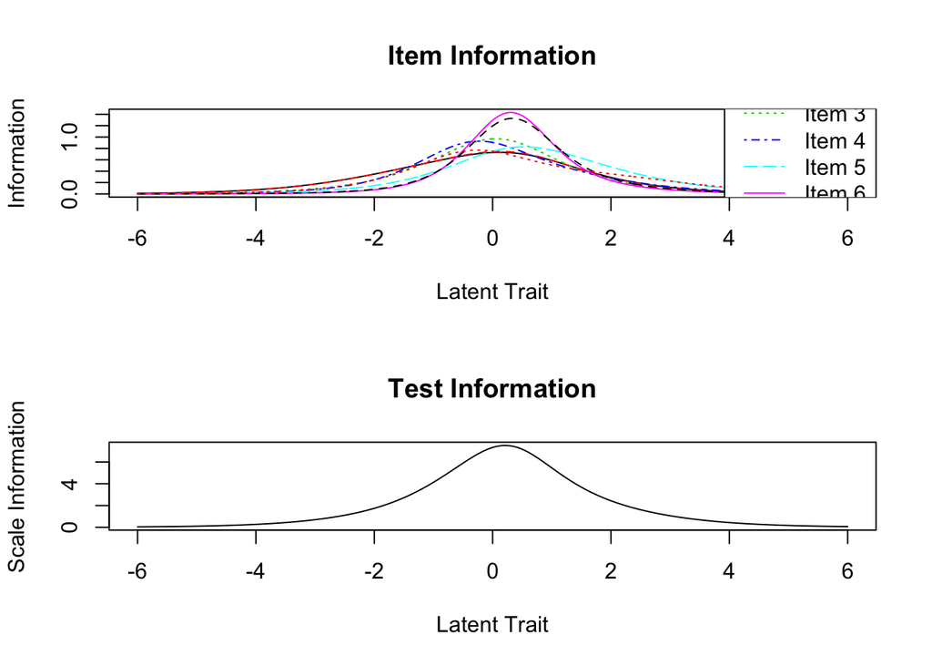

```r
plotINFO(pcm.2, legpos = "right")
```

Plot PW map:

```
## Spline interpolation in some subgroups not performed!
##   Less than 4 different person parameters estimable!
##   Perhaps NAs in subgroup(s).
```

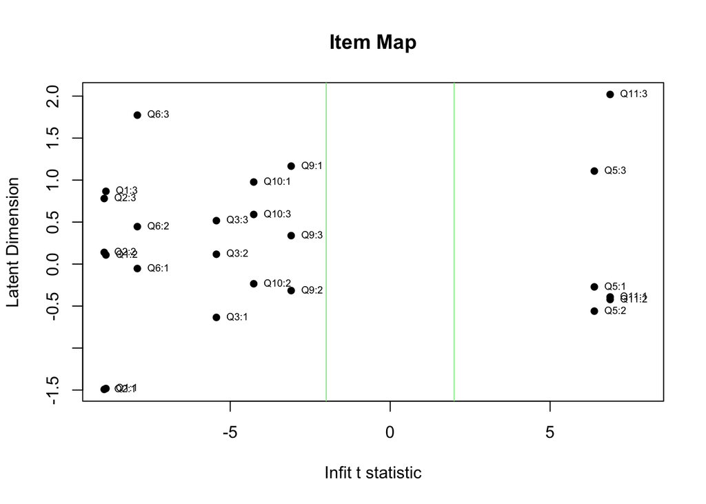

```r
plotPWmap(pcm.2, imap=T)
```

Separation reliability:

```r
SepRel(pres.pcm)
```

```
## Separation Reliability: 0.7564
```

Note XXX to render simpler to just hit Shift Ctrk - K in RStudio… better than including this code here